# Walkthrough script: R for Research day 2

Author

Casey O’Hara

```r
library(tidyverse)
```

# Load the data

```r
sfo_trees_df <- read_csv('sfo_trees_sample.csv')
```

About the data: SF trees data are from the [SF Open Data Portal](https://data.sfgov.org/City-Infrastructure/Street-Tree-List/tkzw-k3nq). See more information from Thomas Mock and TidyTuesday [here](https://github.com/rfordatascience/tidytuesday/tree/master/data/2020/2020-01-28). Data updated 1/10/2024, with certain columns dropped to reduce file size. Additionally, a 10% sample of the full dataset was kept to further reduce file size.

Each row is an observation, in this case, a single tree. Each column is a variable, in this case, information about each of the trees.

# Example 1:

What are the most common legal statuses of trees in San Francisco?

## Pseudocode

- For each legal status code, count up how many observations (trees) are under that code.
- Find the legal codes with the 5 highest totals, and keep those (drop all the others).
- Store the results as `top_5_status`.

```r
sfo_trees_df %>%
  group_by(LegalStatus) %>%
  summarize(tree_count = n())
```

```
# A tibble: 13 × 2
   LegalStatus                     tree_count
   <chr>                                <int>
 1 DPW Maintained                       14357
 2 Landmark tree                           20
 3 Permitted Site                        4031
 4 Planning Code 138.1 required           109
 5 Private                                 24
 6 Property Tree                           33
 7 Prune Opt Out                           15
 8 Section 143                             12
 9 Section 806 (d)                         67
10 Significant Tree                       220
11 Street Tree Maintenance Opt Out          9
12 Undocumented                           857
13 <NA>                                     7
```

```r
top_5_status <- sfo_trees_df %>%
  group_by(LegalStatus) %>%
  summarize(tree_count = n()) %>%
  ungroup() %>%
  slice_max(tree_count, n = 5)
```

Make a ggplot of the top 5 observations from above:

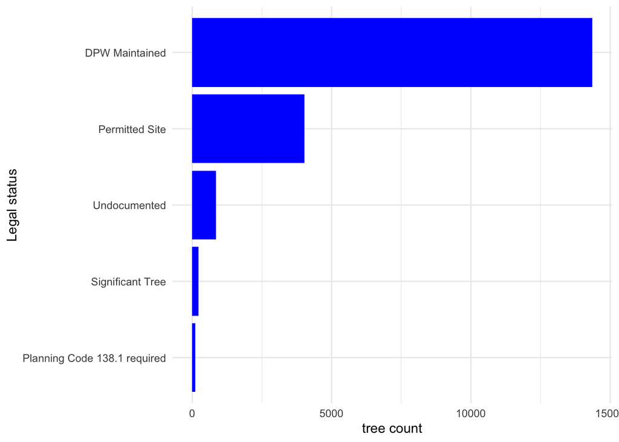

```r
ggplot(top_5_status,
       aes(y = fct_reorder(LegalStatus, tree_count),
           x = tree_count)) +
  geom_col(fill = 'blue') +
  labs(y = 'Legal status', x = 'tree count') +
  theme_minimal()
```

# Example 2

Where are all the oak and pine trees in San Francisco?

## Pseudocode

- Find observations that are either pine or oak trees (of various types); drop the rest.
- Select just the columns: “Species”, “LegalStatus”, “PlantDate”, and “Latitude” and “Longitude”
- For each tree, note whether it’s an oak or a pine!

## Functional code

```r
oak_pine_df <- sfo_trees_df %>%
  filter(str_detect(Species, "Oak") | str_detect(Species, 'Pine')) %>%
  select(Species, LegalStatus, PlantDate, Latitude, Longitude) %>%
  mutate(type = ifelse(str_detect(Species, 'Oak'), 'oak', 'pine'))
```

## Visualize

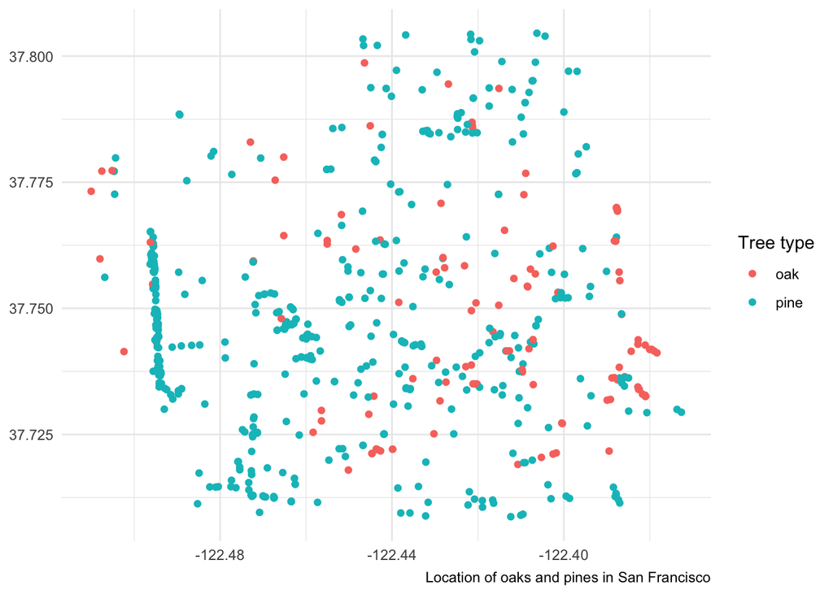

```r
ggplot(data = oak_pine_df, aes(x = Longitude, y = Latitude, color = type)) +
  geom_point() +
  theme_minimal() +
  theme(axis.title = element_blank()) +
  labs(color = 'Tree type',
       caption = 'Location of oaks and pines in San Francisco')
```